# Exploring and Wrangling Fitbit data

Katie Wat

2023-09-27

This dataset is available publicly on [Kaggle](https://www.kaggle.com/datasets/arashnic/fitbit/data).

## Setting up the dataset

1. Examine data struture
2. Set *Id* as a factor

```r
glimpse(dailyActivity) # examine data structure
```

```
## Rows: 940
## Columns: 15
## $ Id                       <dbl> 1503960366, 1503960366, 1503960366, 150396036…
## $ ActivityDate             <chr> "4/12/2016", "4/13/2016", "4/14/2016", "4/15/…
## $ TotalSteps               <int> 13162, 10735, 10460, 9762, 12669, 9705, 13019…
## $ TotalDistance            <dbl> 8.50, 6.97, 6.74, 6.28, 8.16, 6.48, 8.59, 9.8…
## $ TrackerDistance          <dbl> 8.50, 6.97, 6.74, 6.28, 8.16, 6.48, 8.59, 9.8…
## $ LoggedActivitiesDistance <dbl> 0, 0, 0, 0, 0, 0, 0, 0, 0, 0, 0, 0, 0, 0, 0, …
## $ VeryActiveDistance       <dbl> 1.88, 1.57, 2.44, 2.14, 2.71, 3.19, 3.25, 3.5…
## $ ModeratelyActiveDistance <dbl> 0.55, 0.69, 0.40, 1.26, 0.41, 0.78, 0.64, 1.3…
## $ LightActiveDistance      <dbl> 6.06, 4.71, 3.91, 2.83, 5.04, 2.51, 4.71, 5.0…
## $ SedentaryActiveDistance  <dbl> 0, 0, 0, 0, 0, 0, 0, 0, 0, 0, 0, 0, 0, 0, 0, …
## $ VeryActiveMinutes        <int> 25, 21, 30, 29, 36, 38, 42, 50, 28, 19, 66, 4…
## $ FairlyActiveMinutes      <int> 13, 19, 11, 34, 10, 20, 16, 31, 12, 8, 27, 21…
## $ LightlyActiveMinutes     <int> 328, 217, 181, 209, 221, 164, 233, 264, 205, …
## $ SedentaryMinutes         <int> 728, 776, 1218, 726, 773, 539, 1149, 775, 818…
## $ Calories                 <int> 1985, 1797, 1776, 1745, 1863, 1728, 1921, 203…
```

```r
dailyActivity$Id <- as.factor(dailyActivity$Id) # set Id as factor
```

## Take a first look at the dataset

```r
# How many participant were there?
n_ppt <- dailyActivity %>%
  summarize(n_ppt = n_distinct(Id))

# How many days did participants logged their data?
Range <- dailyActivity %>%
  group_by(Id) %>%
  summarize(n_days = n_distinct(ActivityDate)) %>%
  summarize(min_days = min(n_days), max_days = max(n_days), med_days = median(n_days))
```

- There are **33** in this study.
- Participants recorded between **4** and **31** days, with a median of **31** days.

## How much time did participants spent being active daily?

### 1. Prepare dataframes

1. Transform dataframe from wide to narrow, bringing all *Activity Intensity* in first column, and its respective minutes *ActivityMinutes* in the second column.
2. Set *Activity Intensity* as a factor.
3. Rename levels within *Activity Intensity*.

```r
# reshape dataframe from wide to narrow, displaying activity intensity and their respective minutes
# set activity intensity as factor, and change levels names
ActivityMinutes <- dailyActivity %>%
  pivot_longer(cols = 11:14, names_to = "ActivityIntensity", values_to = "ActivityMinutes") %>%
  mutate(ActivityIntensity =  factor(ActivityIntensity, levels = c(unique(ActivityIntensity))),
         ActivityIntensity = fct_recode(ActivityIntensity, Sedentary = "SedentaryMinutes",
                                        LightlyActive = "LightlyActiveMinutes",
                                        FairlyActive = "FairlyActiveMinutes",
                                        VeryActive = "VeryActiveMinutes"))
```

4. Filter out *Sedentary* activity, so we don’t include any minutes that were sedentary.
5. Find total activity minutes by participant and date, which is the sum of *LightlyActive*, *FairlyActive* and *VeryActive* minutes.
6. Calculate **summary statistics** on the duration of activity as a whole.

```r
# How many minutes of activity did participants logged?
Act_stats<- ActivityMinutes %>%
  filter(ActivityIntensity != "Sedentary") %>%
  group_by(Id, ActivityDate) %>%
  summarize(Total_Act_min = sum(ActivityMinutes), cnt = n_distinct(ActivityMinutes)) %>%
  ungroup() %>%
  summarize(Min_Act_min = min(Total_Act_min), Med_Act_min = median(Total_Act_min),
            Avg_Act_min = round(mean(Total_Act_min),0), Max_Act_min = max(Total_Act_min))
```

#### Summary statistics on duration of activities (minutes)

- Minimum: 0
- Median: 247
- Maximum: 552
- Mean: 228

We will use the mean value for the plot below to see how each participant compares to the average time spent being active.

### 2. Make some plots

#### 1. Histogram of average daily activity duration

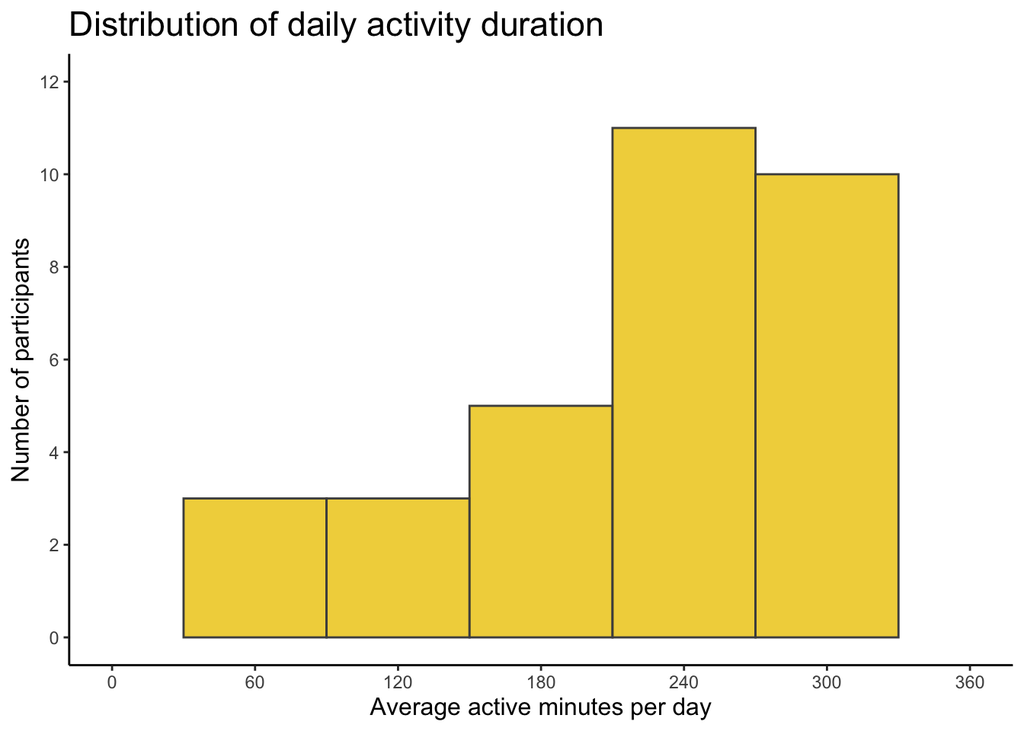

```r
# [plot] histogram of activity duration
ActivityMinutes %>%
  filter(ActivityIntensity != "Sedentary") %>%
  group_by(Id, ActivityDate) %>%
  summarize(total_act_mins = sum(ActivityMinutes)) %>%
  ungroup() %>%
  group_by(Id) %>%
  summarize(avg_act_mins = round(mean(total_act_mins), 1)) %>%

  ggplot(aes(x = avg_act_mins))+
  geom_histogram(binwidth = 60, color = "grey30", fill = "gold2", alpha = 0.8)+
  scale_x_continuous("Average active minutes per day", breaks = seq(0,360,60), limits = c(0,360))+
  scale_y_continuous("Number of participants", breaks = seq(0,12,2), limits = c(0,12))+
  labs(title = "Distribution of daily activity duration")+
  theme_classic()+
  theme(axis.title.x = element_text(size=12),
        axis.title.y = element_text(size = 12),
        title = element_text( size = 14))
```

#### 2. Average daily duration of activities by each participant, sorted by the amout of activities

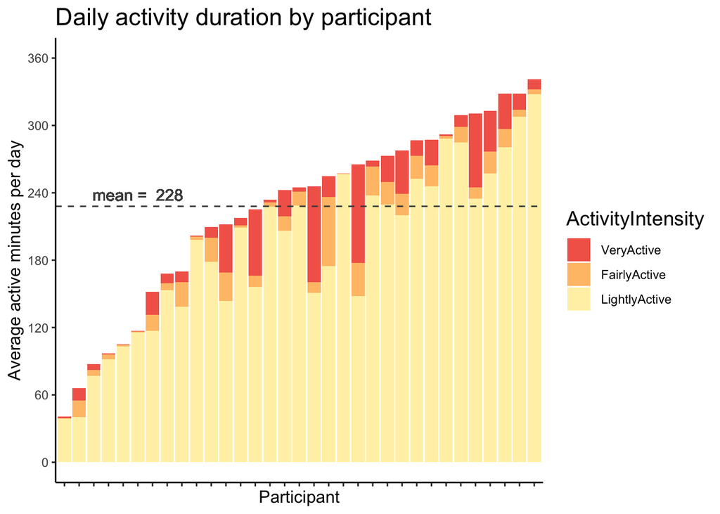

```r
# [plot] Average active minutes per day by participant
ActivityMinutes %>%
  filter(ActivityIntensity != "Sedentary") %>%
  group_by(Id, ActivityIntensity) %>%
  summarize(avg_act_mins = mean(ActivityMinutes)) %>% # avg active minutes by activity intensity and person across days

  ggplot(aes(x = fct_reorder(Id, avg_act_mins, .fun=sum), y = avg_act_mins))+
  geom_col(aes(fill = ActivityIntensity), alpha = 0.8)+
  geom_hline(yintercept = Act_stats$Avg_Act_min, linetype="dashed", color = "grey30")+
  scale_y_continuous("Average active minutes per day", breaks = seq(0,360,60), limits = c(0,360))+
  scale_x_discrete("Participant")+
  labs(title = "Daily activity duration by participant")+
  scale_fill_brewer(palette = "YlOrRd", direction = -1)+
  geom_text(aes(6, Act_stats$Avg_Act_min, label = paste("mean = ", Act_stats$Avg_Act_min), vjust = -0.5), color = "grey30", size = 4)+
  theme_classic()+
  theme(axis.text.x = element_blank(),
        axis.title.x = element_text(size=12),
        axis.title.y = element_text(size = 12),
        title = element_text( size = 14))
```

- A large proportion of activity was in **light intensity**.

## Next Steps

- Explore more on activity data, discover any daily/ weekly activity patterns
- Explore from other data tables, including Sleep hours and step count